# Statistical inference with the GSS data

Ernâni de Britto Murtinho (ernanibmurtinho@gmail.com)

## Setup

### Load packages

```r
library(ggplot2)
library(dplyr)
library(statsr)
```

### Load data

```r
load("gss.Rdata")

#renaming for convenience

df <- gss
```

### Cleaning and visualizing the Data

```r
df_gss <- select(df, caseid, degree, educ, natfare, age, income06, coneduc, conmedic, coninc) %>%
   filter(degree != "NA") %>% filter(educ != "NA") %>% filter(natfare != "NA") %>% filter(age != "NA") %>% filter(income06 != "NA") %>% filter(coneduc != "NA") %>% filter(conmedic != "NA") %>% filter(coninc != "NA")
head(df_gss, 20)
```

```
##    caseid         degree educ     natfare age           income06
## 1   46511    High School   13    Too Much  50    $30000 To 34999
## 2   46523       Bachelor   16  Too Little  26    $8 000 To 9 999
## 3   46524       Bachelor   16 About Right  60    $40000 To 49999
## 4   46529    High School   13  Too Little  25    $4 000 To 4 999
## 5   46532    High School   12 About Right  69    $8 000 To 9 999
## 6   46554 Lt High School   10    Too Much  79    $25000 To 29999
## 7   46564       Graduate   18  Too Little  30    $60000 To 74999
## 8   46565       Bachelor   18 About Right  36 $110000 To $129999
## 9   46571    High School   13 About Right  52    $17500 To 19999
## 10  46575    High School   12 About Right  59    $30000 To 34999
## 11  46586       Graduate   18    Too Much  36 $110000 To $129999
## 12  46595    High School   12 About Right  74    $30000 To 34999
## 13  46600 Lt High School   10 About Right  33    $50000 To 59999
## 14  46603 Lt High School   10 About Right  44    $40000 To 49999
```

[output cut: 27 more lines]

# Variables used

caseid -> case identification number degree -> RS highest degree natfare -> welfare age -> age income06 -> total family income coneduc -> education confidence conmedic -> medicine confidence coninc -> FAMILY INCOME IN CONSTANT DOLLARS

# CASEID

## CASE IDENTIFICATION NUMBER

# DEGREE

## RS HIGHEST DEGREE

If finished 9th-12th grade: Did you ever get a high school diploma or a GED certificate?

# INCOME06

## TOTAL FAMILY INCOME

In which of these groups did your total family income, from all sources, fall last year before taxes, that is.

# CONEDUC

## CONFIDENCE IN EDUCATION

I am going to name some institutions in this country. As far as the people running these institutions are concerned, would you say you have a great deal of confidence, only some confidence, or hardly any confidence at all in them? d. Education.

# CONMEDIC

## CONFIDENCE IN MEDICINE

I am going to name some institutions in this country. As far as the people running these institutions are concerned, would you say you have a great deal of confidence, only some confidence, or hardly any confidence at all in them? h. Medicine.

## Part 1: Data

### Introduction

The General Social Survey (GSS) is a sociological survey created and regularly collected since 1972 by the research institute [NORC](http://www.norc.org/Research/Projects/Pages/general-social-survey.aspx) at the University of Chicago. It is funded by the National Science Foundation. The GSS collects information and keep a historical record of the concerns, experiences, attitudes, and practices of residents of the United States.

### Data Usage

The propose of this project, is to use the data with educational purposes and others, related to trends, changes, behavioral comportaments, functioning overview of society as well as the role of various sub-groups. A comparative between United States and other societies to place American society in comparative perspective and develop cross-national models of human society. Make a up-to-date dataset, with high-quality and acessible to scholars, students, policy makers and others, with low cost.

### Generalizability

This Data(the GSS Survey) is targeted to adults (18+) (residents in U.S.) living in households. Respondents that become part of the GSS sample are from a mix of urban, suburban, and rural geographic areas. The participation in this study is strictly voluntary and the survey is conducted by a face-to-face interview.

### Causality

This data is experimental and, otherwise, doesn’t provide none causal conclusions.

## Part 2: Research question

Is there a correlation between better health conditions/requirements and high school degree(a higher education level)?

Here, I will take an overview of the topics “family income level” and “education”(two of the principals, for a society, in my opinion) because a higher family income, could reflect in better life conditions(I know that correlation doesn’t imply causation) but it’s one of the starting points.

If the people in a country, have better income and education conditions, that may provide a better access to hospitals, greater realizations of dreams and desires in a society and stimulates their growth as a whole, leading everyone together to walk the same path.

Well, lets see how it reflects in a society with a litle example:

## Part 3: Exploratory data analysis

```r
str(df_gss)
```

```
## 'data.frame':    2540 obs. of  9 variables:
##  $ caseid  : int  46511 46523 46524 46529 46532 46554 46564 46565 46571 46575 ...
##  $ degree  : Factor w/ 5 levels "Lt High School",..: 2 4 4 2 2 1 5 4 2 2 ...
##  $ educ    : int  13 16 16 13 12 10 18 18 13 12 ...
##  $ natfare : Factor w/ 3 levels "Too Little","About Right",..: 3 1 2 1 2 3 1 2 2 2 ...
##  $ age     : int  50 26 60 25 69 79 30 36 52 59 ...
##  $ income06: Factor w/ 26 levels "Under $1 000",..: 16 8 18 4 8 15 20 23 12 16 ...
##  $ coneduc : Factor w/ 3 levels "A Great Deal",..: 2 3 2 3 2 2 2 2 2 2 ...
##  $ conmedic: Factor w/ 3 levels "A Great Deal",..: 1 3 2 2 1 2 2 2 3 2 ...
##  $ coninc  : int  28668 7939 39695 3969 7939 24258 59542 105852 16539 28668 ...
```

```r
dim(df_gss)
```

```
## [1] 2540    9
```

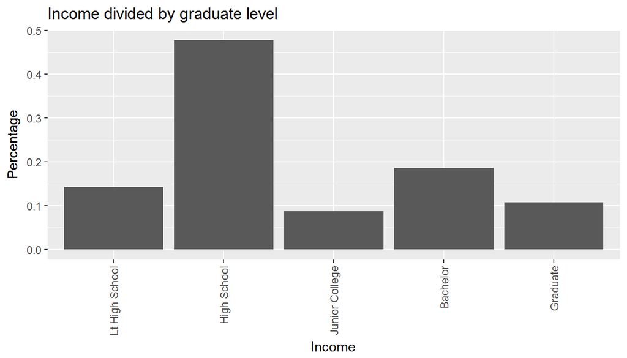

```r
# Preparing the Data

#Division between graduation levels, low when the person doesn't have a regular bachelor and high when the person has a bachelor or a higher level, a master degree or beyond that.

high_grad_val <- c("Bachelor", "Graduate")

high_grad <- subset(df_gss, df_gss$degree %in% high_grad_val)
low_grad <- subset(df_gss, !(df_gss$degree %in% high_grad_val))

#Agregating the income level by degree

high_grad_graph <- high_grad %>%
  group_by(income06) %>%
  summarise(frequency = n()) %>%
  mutate(percentage = frequency / sum(frequency))

low_grad_graph <- low_grad %>%
  group_by(income06) %>%
  summarise(frequency = n()) %>%
  mutate(percentage = frequency / sum(frequency))

#Agregating by high and low degree, as above.

gss_degree_group <- df_gss %>% group_by(degree) %>% summarise (n = n()) %>% mutate(percentage = n / sum(n))

#Agregating by degree and natfare, for try to see a correlation between both.

gss_degree_natfare <- df_gss %>% group_by(degree, natfare) %>% summarise (n = n()) %>% mutate(percentage = n / sum(n)) %>% arrange(natfare)

ggplot(gss_degree_group, aes(x=degree, y = percentage)) +
  geom_bar(stat="identity") +
  theme(axis.text.x=element_text(angle=90,hjust=1,vjust=0.5)) +
  labs(x="Income", y="Percentage") +
  ggtitle("Income divided by graduate level")
```

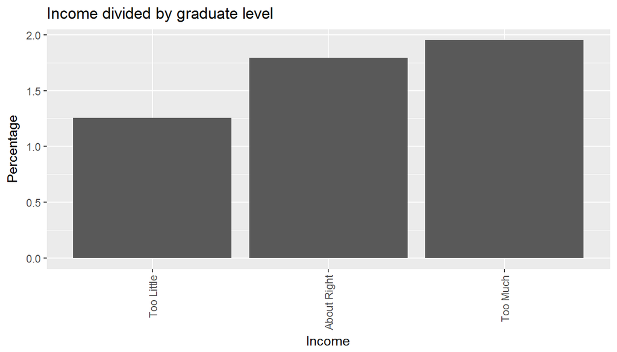

```r
ggplot(gss_degree_natfare, aes(x=natfare, y = percentage)) +
  geom_bar(stat="identity") +
  theme(axis.text.x=element_text(angle=90,hjust=1,vjust=0.5)) +
  labs(x="Income", y="Percentage") +
  ggtitle("Income divided by graduate level")
```

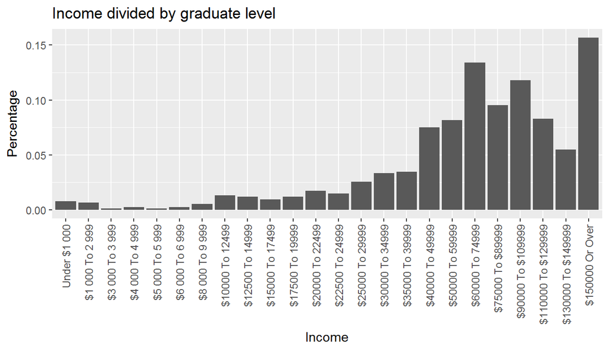

```r
ggplot(high_grad_graph, aes(x=income06, y = percentage)) +
  geom_bar(stat="identity") +
  theme(axis.text.x=element_text(angle=90,hjust=1,vjust=0.5)) +
  labs(x="Income", y="Percentage") +
  ggtitle("Income divided by graduate level")
```

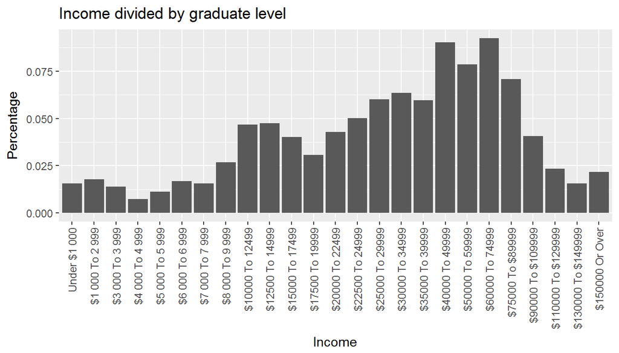

```r
ggplot(low_grad_graph, aes(x=income06, y = percentage)) +
  geom_bar(stat="identity") +
  theme(axis.text.x=element_text(angle=90,hjust=1,vjust=0.5)) +
  labs(x="Income", y="Percentage") +
  ggtitle("Income divided by graduate level")
```

```r
#Preparing Data - changing factor to numeric, for use to correlation

df_gss <- df_gss %>%
  mutate(coneducCor = ifelse(coneduc == 'Only Some', 1,
                    ifelse(coneduc == 'A Great Deal', 2, 3 ))) %>%
  mutate(conmedicCor = ifelse(conmedic == 'Only Some', 1,
                    ifelse(conmedic == 'A Great Deal', 2, 3)))

#Here, we will take a look if confidence education and confidence in medical services, has an important correlation

cor(df_gss$coneducCor, df_gss$conmedicCor)
```

```
## [1] 0.1237434
```

```r
#Correlation apointed here, is not a high value and have a little but estimated correlation

by(df_gss$conmedic, df_gss$coneduc, summary)
```

```
## df_gss$coneduc: A Great Deal
## A Great Deal    Only Some   Hardly Any
##          379          239           42
## --------------------------------------------------------
## df_gss$coneduc: Only Some
## A Great Deal    Only Some   Hardly Any
##          502          823          142
## --------------------------------------------------------
## df_gss$coneduc: Hardly Any
## A Great Deal    Only Some   Hardly Any
##          101          211          101
```

```r
#Now, we can conclude that, even though there is a pretty association between degree level and welfare, sometimes they have a connection.

#
```

## Part 4: Inference

```r
#Here we hope we can investigate if there is a relationship between family income level, education and welfare, as we have seen before.

#And, at this end, we will test the null hypothesis H0 that the high graduate have better life conditions and alternative Hypothesis that low graduate have worst life conditions.

#For comparison proposes, we wiil look at the mean, of these hypothesis

df_gss %>%
  group_by(degree) %>%
  summarise(mean_degree = mean(n()))
```

```
## # A tibble: 5 x 2
##           degree mean_degree
##           <fctr>       <dbl>
## 1 Lt High School         361
## 2    High School        1212
## 3 Junior College         221
## 4       Bachelor         473
## 5       Graduate         273
```

```r
df_gss %>%
  group_by(natfare) %>%
  summarise(mean_natfare = mean(n()))
```

```
## # A tibble: 3 x 2
##       natfare mean_natfare
##        <fctr>        <dbl>
## 1  Too Little          622
## 2 About Right          899
## 3    Too Much         1019
```

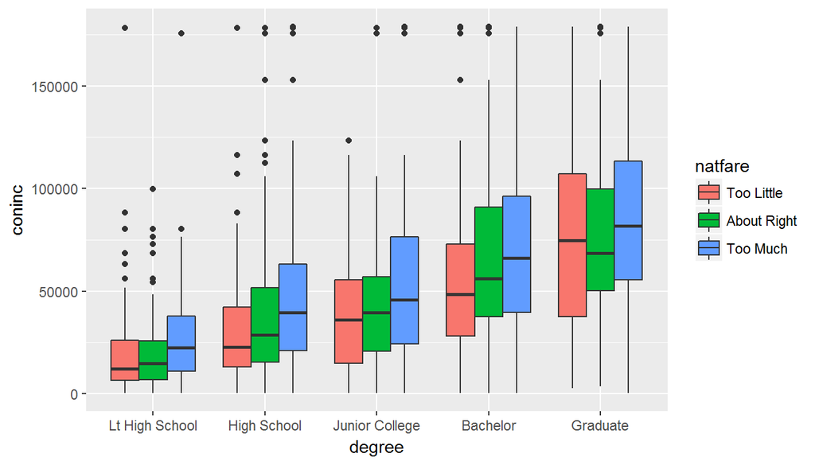

```r
#Lets visualize the data, for inference information, making an analysis between degree and natfare by coninc(family income in dollars).

ggplot(data=df_gss,aes(x=degree,y=coninc)) + geom_boxplot(aes(fill=natfare))
```

```r
#The plot show us that we have a proportionally growth between this comparisons, but sometimes the plot may not show everything we need to know. Even though the plot is growing proportionally, it's not the only truth.

#Lets take a look at anova analysis:

anova(lm(coninc ~ degree, data = df_gss))
```

```
## Analysis of Variance Table
##
## Response: coninc
##             Df     Sum Sq    Mean Sq F value    Pr(>F)
## degree       4 9.1570e+11 2.2893e+11     157 < 2.2e-16 ***
## Residuals 2535 3.6962e+12 1.4581e+09
## ---
## Signif. codes:  0 '***' 0.001 '**' 0.01 '*' 0.05 '.' 0.1 ' ' 1
```

```r
anova(lm(coninc ~ natfare, data = df_gss))
```

```
## Analysis of Variance Table
##
## Response: coninc
##             Df     Sum Sq    Mean Sq F value    Pr(>F)
## natfare      2 9.0161e+10 4.5081e+10  25.293 1.329e-11 ***
## Residuals 2537 4.5218e+12 1.7823e+09
## ---
## Signif. codes:  0 '***' 0.001 '**' 0.01 '*' 0.05 '.' 0.1 ' ' 1
```

```r
#Lets perform the pairwise t-tests with the Bonferonni correction.

pairwise.t.test(df_gss$coninc, df_gss$degree, p.adj="bonferroni")
```

```
##
##  Pairwise comparisons using t tests with pooled SD
##
## data:  df_gss$coninc and df_gss$degree
##
##                Lt High School High School Junior College Bachelor
## High School    3.6e-12        -           -              -
## Junior College 7.0e-15        0.0048      -              -
## Bachelor       < 2e-16        < 2e-16     7.4e-11        -
## Graduate       < 2e-16        < 2e-16     < 2e-16        3.9e-05
##
## P value adjustment method: bonferroni
```

```r
pairwise.t.test(df_gss$coninc, df_gss$natfare, p.adj="bonferroni")
```

```
##
##  Pairwise comparisons using t tests with pooled SD
##
## data:  df_gss$coninc and df_gss$natfare
##
##             Too Little About Right
## About Right 2.3e-05    -
## Too Much    4.5e-12    0.016
##
## P value adjustment method: bonferroni
```

Conclusion

Our P-value is close to zero, in these two cases, that indicates to us, that we have a strong evidence that income and education levels, together, these shows that if you have a better education, this may infer in a better life conditions expected, which is not always the truth, but we have a strongest evidence that it can makes everything better in a nation.